# Statistics UTA

```r
knitr::opts_chunk$set(echo = "TRUE")
library(tidyverse)
```

### Comprehension Check

Below are the first four rows of data from a survey of incoming university freshmen:  
ID Ethnicity Major Freshman Orientation HS Sports Math GPA  
001 White Biology Yes 1 3.1  
002 Asian Art History No 0 3.4  
003 Hispanic Computer Science Yes 0 3.9  
004 Hispanic Undecided Yes 1 2.3

problem  
4/4 points (graded)  
The ethnicity of each student is what kind of variable?  
identifier variable  
*categorical (qualitative) correct*  
numerical (quantitative)  
cannot be determined without additional information

The Math GPA for each student is what kind of variable?  
identifier variable  
categorical (qualitative)  
*numerical (quantitative) correct* cannot be determined without additional information

Each student was asked, “Did you play sports in high school?” Their responses were recorded as “1” for YES and “0” for NO. What kind of data do you have now?  
*It is still categorical data, even though numbers are used to represent categories. correct*  
It is numerical data, because 0 and 1 are numbers.  
It is no longer data. The data has been modified from its original format.  
It is numerical data because we can count how many 0’s and 1’s we have, and you can’t do that with categorical data.

Which of the following would NOT be considered raw data?  
Height of each skyscraper in Manhattan.  
Highest grade level completed by each of 16 taxicab drivers in Queens.  
*Average age of ballet dancers attending The Juilliard School. correct*  
Highest temperature recorded each day of June 2014 in the Bronx.

Below are examples of data:  
Jersey numbers of five players on an NBA basketball team  
Length (in seconds) of each song on a Michael Jackson album.  
Top five best‐selling books on the New York Times bestsellers list.  
Height of children in a kindergarten class  
problem  
2/2 points (graded)  
Only one of the following scales of measurement is not represented above. Which is it?  
ordinal  
*interval correct* nominal  
ratio  
Which of the following is an example of interval data being converted to ordinal data?  
Finish times for a marathon reported as first, second and third place, etc.  
Age recorded as infant, youth, adult, and senior.  
Winter temperatures graphed in categories of 30‐39, 40‐49, 50‐59, and 60‐69 degree Fahrenheit.  
*Happiness scores (measured on a scale of 1‐10) recorded as not happy, happy, and very happy. correct*

```r
library(SDSFoundations)
```

```r
table(BikeData$cyc_freq)
```

[output not shown]

```r
bikePlot <- ggplot(BikeData,
                   aes(x = distance, y = time))
bikePlot +
        geom_point(aes(col = gender))
```

[output not shown]

### Indexing data frames

Viewing a specific variable BikeData[2, 5]

1

View all rows for one variable BikeData[, 5] `BikeData[, 5]`

view counts of the specified variable table(BikeData$gender) 31, 90

create an object with all females from the dataset females <- BikeData[BikeData$gender == ‘F’, ]

head(females)

| user_id | age | gender | student | employed | cyc_freq | distance | time | speed |
| --- | --- | --- | --- | --- | --- | --- | --- | --- |
| 4 | 44 | F | 0 | 1 | Less than once a month | 3.24 | 24 | 8.10 |
| 18 | 32 | F | 1 | 1 | Daily | 9.34 | 40 | 14.01 |
| 21 | 51 | F | 0 | 1 | Several times per week | 3.40 | 21 | 9.71 |
| 24 | 30 | F | 0 | 1 | Several times per week | 4.89 | 19 | 15.44 |
| 27 | 27 | F | 0 | 1 | Several times per week | 0.87 | 6 | 8.70 |
| 29 | 27 | F | 0 | 1 | Several times per week | 3.09 | 22 | 8.43 |

gather the female speeds femaleSpeeds <- BikeData$speed[BikeData$gender == ‘F’]

head(femaleSpeeds) 8.1, 14.01, 9.71, 15.44, 8.7, 8.43

mean of female speeds: mean(femaleSpeeds) = 13.6551613

### Week 1 Welcome to Pre Lab!

In 2011, researchers at the Texas Transportation Institute and the Center for Transportation Research at UT Austin ran an advertising campaign aimed at recruiting Austin cyclists to join the South Congress Bike Mapping Project. As members of the project, cyclists downloaded and used Cycle Tracks, a smartphone app developed by the San Francisco County Transportation Authority to track where people are riding their bikes based on their GPS points. The goal was to gain new information about bike commuting patterns and this data set is based on the results of the study: 3600 trips tracked from 315 users over a 6 month period. Data includes distances traveled, speed of travel, and reasons for travel among other variables.

**How many of the cyclists were students, how often did they ride, and what was the average distance they rode?**

#### Check the Data

We will always begin by checking the data. Follow the directions below.

Let’s begin by examining our data in R.

1. Open RStudio. Make sure you’ve installed the current version of the SDSFoundations package.
2. Type library(SDSFoundations) This will automatically load the data for the labs.
3. Type bike <- BikeData This will assign the data to your Workspace.
4. Look at the spreadsheet view of the data to answer the following questions.

Alternatively, you can use follow the steps in the “Importing a Data Frame” R tutorial video, and use the BikeData.csv file. (Right-click and “Save As.”) Make sure to name the dataframe “bike” when importing.

1. Open RStudio.
2. Click on “Import Dataset” button at the top of the workspace window. Choose “from text file.”
3. Click on the location of the BikeData.csv file you just downloaded.
4. Click on the BikeData.csv file. Then, click Upload.
5. Look at the spreadsheet view of the data to answer the following questions.

Can you locate the answers to these questions by looking at the data frame?

Can you locate the answers to these questions by looking at the data frame?

1a. What is the age of the 7th rider in the dataset?

45 correct  
45 1b. How many of the first 10 riders in the dataset ride daily?

3 correct  
3 1c. What is the speed of the first female who cycles less than one time per month (in miles/hour)?

8.10 correct  
8.10 Submit You have used 1 of 1 attempt Some problems have options such as save, reset, hints, or show answer. These options follow the Submit button.

Show Answer Correct (3/3 points) Review problem 3/3 points (graded) Check the Variables of Interest

You will be asked in pre-lab to examine the variables of interest and correctly categorize them. For example:

2a. What type of variable is student? categorical  
2b. What type of variable is cyc_freq? categorical  
2c. What type of variable is distance? numerical  
Submit You have used 1 of 1 attempt Some problems have options such as save, reset, hints, or show answer. These options follow the Submit button.

Show Answer Correct (3/3 points) Review problem 1/1 point (graded) Reflect on the Method

You will be asked a few questions about the method you will be using in lab. Since this is a practice lab, we will ask you about R basics.

3. In this lab, we will be creating a new dataset that includes just the student riders and all of their variables. What is the correct terminology for this new dataset?

data frame correct index table vector

### Primary Research Question

**How many of the cyclists were students, how often did they ride, and what was the average distance they rode?**

Let’s break this analysis into its required steps:

1. Find the number of students in the dataset.
2. Pull out the student data into a separate dataframe for analysis.
3. Make a table to find how often the students ride.
4. Find the average distance ridden.

```r
table(bike$student)
```

```
  0   1
107  14
```

Pull out student data into a new dataframe: student <- bike[bike$student ==1, ]

Find how often the students ride, using the new dataframe: table(student$cyc_freq) 8, 0, 0, 6

Create a vector for the distance variable: distance <- student$distance

Find average distance ridden: mean(studentDistance) 6.2578571

2. What is the role of the comma? *It tells R to include all the variables (columns) for the riders that are students. > correct* It tells R to include all the students (rows), beginning with the first one.
3. What does “student” refer to in this line of code?: table(student$cyc_freq)

the original variable called “student” *the new dataframe called “student” correct*

This line of code creates a vector called “distance:” distance <-student$distance

4. What does this vector consist of? *It is a string of numbers, each of which is the distance ridden by a student in the dataset. correct* It is a matrix of numbers, showing all the distances ridden by each student.

Suppose we have run the following code to try to create a list of the times. Read in the dataset and name it bike bike<-BikeData Create a vector of the times rider_times<-bike$times Check the contents of our rider_times vector rider_times

5. What error has caused the vector of rider_times to be empty? (Examine the data set in R for help.) We should have named the vector “time” instead. *The variable “times” is not spelled the same way in our datafile. correct* We cannot check the contents of vectors in R. We cannot use an underscore when naming vectors.
6. How many students are in the dataset? (Hint: Look at the output for table(bike$student).) 14
7. How many variables are in the new data frame “student”? (Hint: Look in your Workspace for the new dataframe.) 9
8. We want to know how often the students ride. What is the most frequently observed response? Daily correct Less than once a month Several times per month Several times per week
9. How is the vector “distance” described in the workspace? 9 variables 14 obs. of 9 variables *num[1:14] correct*
10. How far do students ride on average? (Round to the nearest 0.01) 3.87 miles *6.26 miles correct* 12.9 miles

### LAB

table(bike$cyc_freq)

47, 2, 14, 58

males <- bike[bike$gender == ‘M’, ]  
females <- bike[bike$gender == ‘F’, ]

table(males$cyc_freq) 38, 0, 9, 43

daily <- bike[bike$cyc_freq == “Daily”,]  
dailyF <- daily[daily$gender == ‘F’, ]  
dailyM <- daily[daily$gender == ‘M’, ]

dailyFAge <- dailyF$age  
dailyMAge <- dailyM$age

mean(dailyFAge): 32.5555556  
mean(dailyMAge): 33.9210526  
table(daily$gender): 9, 38

### Chapter 2 Readings

```r
material <- c("Aluminum Cans", "Copper Wire", "Steel Cans", "LDPE Plastics (e.g., trash bags)" , "PET Plastics (e.g., beverage bottles)", "HDPE Plastics (e.g., household cleaner bottles)", "Personal Computers", "Carpet", "Glass", "Corrugated Cardboard", "Newspaper", "Phone Books", "Magazines", "Office Paper")

energy <- c(206, 83, 20, 56, 53, 51, 43, 106, 2, 15, 16, 11, 11, 10)

data <- data_frame(material, energy)
```

### 2.1 Freequency Tables

**material**  
Aluminum Cans, Copper Wire, Steel Cans, LDPE Plastics (e.g., trash bags), PET Plastics (e.g., beverage bottles), HDPE Plastics (e.g., household cleaner bottles), Personal Computers, Carpet, Glass, Corrugated Cardboard, Newspaper, Phone Books, Magazines, Office Paper **energy**  
206, 83, 20, 56, 53, 51, 43, 106, 2, 15, 16, 11, 11, 10  
**data**

| material | energy |
| --- | --- |
| Aluminum Cans | 206 |
| Copper Wire | 83 |
| Steel Cans | 20 |
| LDPE Plastics (e.g., trash bags) | 56 |
| PET Plastics (e.g., beverage bottles) | 53 |
| HDPE Plastics (e.g., household cleaner bottles) | 51 |
| Personal Computers | 43 |
| Carpet | 106 |
| Glass | 2 |
| Corrugated Cardboard | 15 |

[output cut: 4 more lines]

Frequency Table with arbitrary bins: freqtbl <- ftable(data)

#### Bin the Data

assign breaks of size 25 to the defined range  
breaks <- seq(min(rng), max(rng) + by, by = by)

apply the breaks to the numerical variable  
energy.cut <- cut(energy, breaks = breaks, right = FALSE)  
data$bin <- cut(energy, breaks = breaks, right = FALSE)

Frequency table with specific bins: table(energy.cut)  
7, 2, 2, 1, 1, 0, 0, 0, 1

display the frequency table cbind(energy.freq)  
7, 2, 2, 1, 1, 0, 0, 0, 1

```r
energy.relfreq
```

```
energy.cut
   [2,27)   [27,52)   [52,77)  [77,102) [102,127) [127,152) [152,177) [177,202) [202,227)
    0.500     0.143     0.143     0.071     0.071     0.000     0.000     0.000     0.071
```

display the frequency and relative frequency: cbind(energy.freq, energy.relfreq)  
7, 2, 2, 1, 1, 0, 0, 0, 1, 0.5, 0.143, 0.143, 0.071, 0.071, 0, 0, 0, 0.071

display the frequency, relative frequency, cumulative frequency, and cumulative relative frequency: cbind(energy.freq, energy.relfreq, energy.cumfreq, energy.cumrelfreq)  
7, 2, 2, 1, 1, 0, 0, 0, 1, 0.5, 0.143, 0.143, 0.071, 0.071, 0, 0, 0, 0.071, 7, 9, 11, 12, 13, 13, 13, 13, 14, 0.5, 0.643, 0.786, 0.857, 0.929, 0.929, 0.929, 0.929, 1

### 2.2 Graphs for Categorical Variables

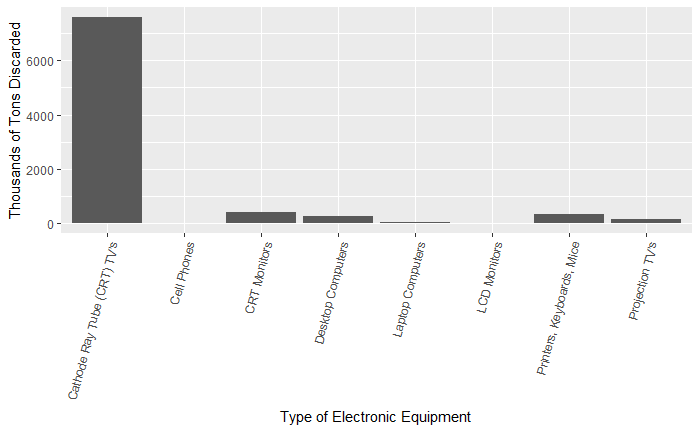

**electronic equipment**  
Cathode Ray Tube (CRT) TVs, CRT Monitors, Printers, Keyboards, Mice, Desktop Computers, Laptop Computers, Projection TVs, Cell Phones, LCD Monitors

**tons discarded**  
7591.1, 389.8, 324.9, 259.5, 30.8, 132.8, 11.7, 4.9

**categorical data**

| electronicEquipment | tonsDiscarded |
| --- | --- |
| Cathode Ray Tube (CRT) TV’s | 7591.1 |
| CRT Monitors | 389.8 |
| Printers, Keyboards, Mice | 324.9 |
| Desktop Computers | 259.5 |
| Laptop Computers | 30.8 |
| Projection TV’s | 132.8 |
| Cell Phones | 11.7 |
| LCD Monitors | 4.9 |

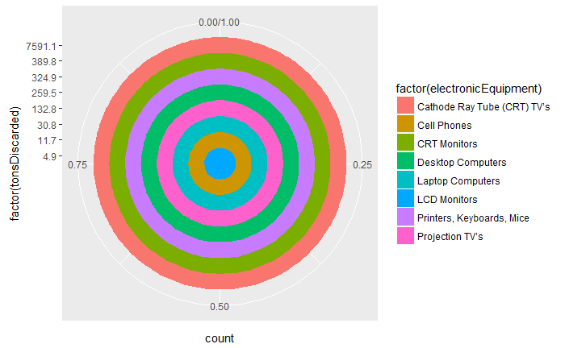

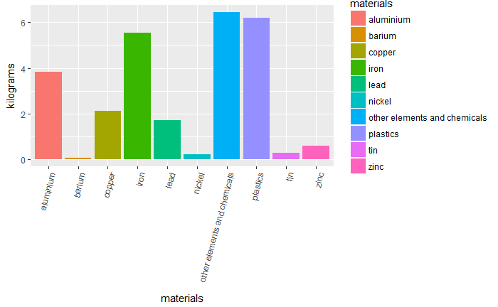

### 2.3 Graphs for Quantitative Data

#### DotCharts, Stem and Leaf

```r
stem.leaf.backback(recycledGlass$glassRecyled, recycledPaper$paperRecycled, back.to.back = FALSE)
```

```
________________________________
  1 | 2: represents 12, leaf unit: 1
recycledGlass$glassRecyled
                   recycledPaper$paperRecycled
________________________________
   0 |4        1  |
   1 |            |
   2 |17       3  |
   3 |49       5  |4        1
   4 |14       7  |002      4
   5 |6669    (4) |69       6
   6 |4        8  |236     (3)
   7 |26       7  |000006  10
   8 |16       5  |333      4
   9 |68       3  |8        1
  10 |0        1  |
________________________________
n:    19           19
________________________________
```

#### Histograms

| bottle.freq | bottle.relfreq | bottle.cumfreq | bottle.cumrelfreq |
| --- | --- | --- | --- |
| 1 | 0.03 | 1 | 0.031 |
| 1 | 0.03 | 2 | 0.062 |
| 3 | 0.09 | 5 | 0.156 |
| 4 | 0.12 | 9 | 0.281 |
| 6 | 0.19 | 15 | 0.469 |
| 8 | 0.25 | 23 | 0.719 |
| 7 | 0.22 | 30 | 0.938 |
| 2 | 0.06 | 32 | 1.000 |

#### Comprehension Check Chapter 2 Reading

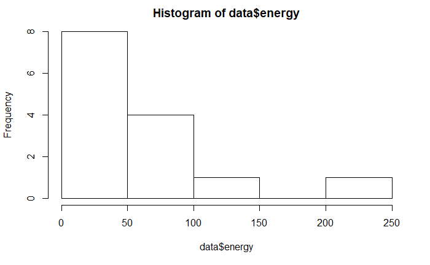

### 2.4 Shapes of Distributions

Bell shapes - unimodal - normally distributed (bell curve)

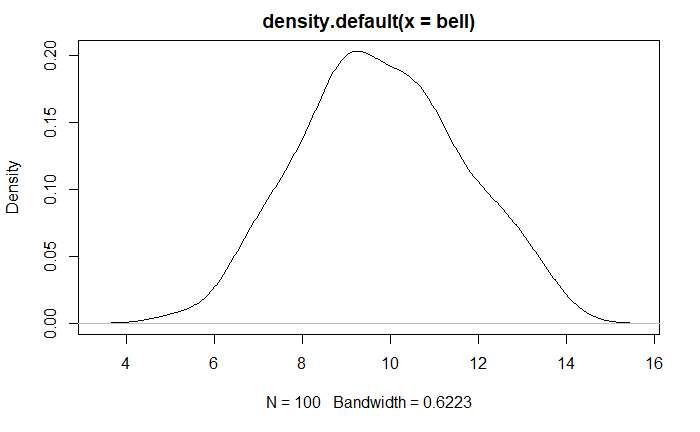

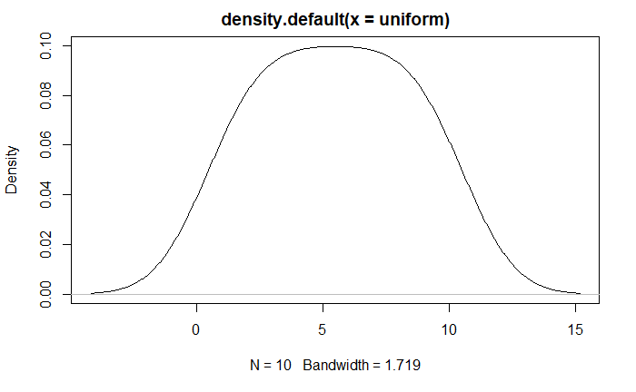

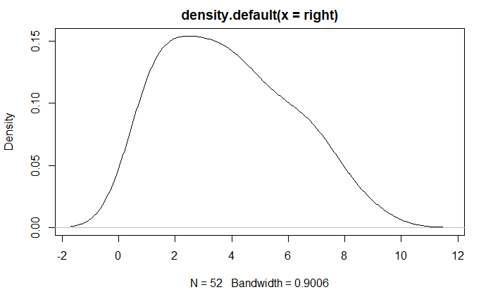

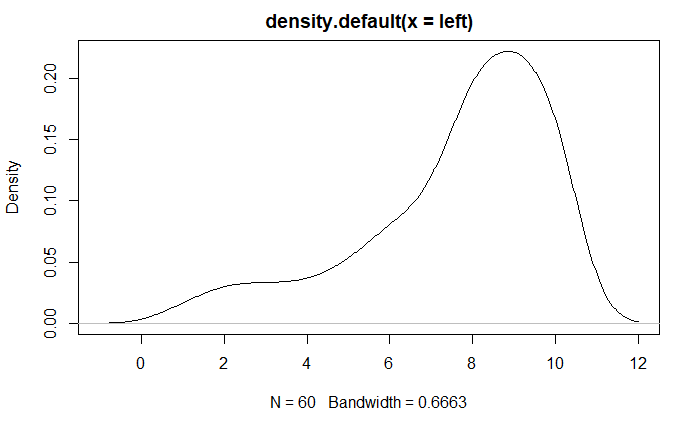

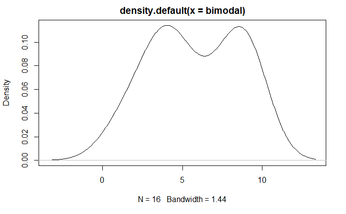